# Relatório da Escala de Crenças e Práticas

Guilherme e Jéssica

13-11-2014

# 1 Introdução

Este relatório objetiva apresentar as análises introdutória do instrumento “Escala de práticas na prevenção do uso de álcool e outras drogas”, que está em fase de desenvolvimento pelo [Centro de Referência em Pesquisa, Intervenção e Avaliação em Álcool e Outras Drogas](http://www.ufjf.br/crepeia/).

O instrumento foi validado para educadores.. O objetivo da pesquisa é oferecer uma medida confiável para avaliação das crenças e práticas de educadores de um curso à distância oferecido pela Secretaria Nacional de Políticas sobre Drogas para aproximadamente 10.000 educadores dos estados de Minas Gerais, Rio de Janeiro e Paraná.

Durante todo o processo de desenvolvimento, foram utilizadas ferramentas de código-aberto, para facilitar o re-uso das técnicas e procedimentos desenvolvidos. Todo conteúdo do instrumento e de suas etapas estará disponível para o público no repositório (http://github.com/crepeia/ead-senad). Atualmente, o projeto está hospedado no repositório (http://github.com/henriquepgomide/ead-senad).

Neste relatório são apresentadas, análises da escala com base em uma amostra de 136 educadores-tutores do curso. As análises foram conduzidas através da linguagem de programação R usando os pacotes *car* e *psych*.

- R Core Team (2014). R: A language and environment for statistical computing. R Foundation for Statistical Computing, Vienna, Austria. URL http://www.R-project.org/.
- John Fox and Sanford Weisberg (2011). An {R} Companion to Applied Regression, Second Edition. Thousand Oaks CA: Sage. URL: http://socserv.socsci.mcmaster.ca/jfox/Books/Companion
- Revelle, W. (2014) psych: Procedures for Personality and Psychological Research, Northwestern University, Evanston, Illinois, USA, http://CRAN.R-project.org/package=psych Version = 1.4.8.

## 1.1 Banco de Dados

O banco de dados da pesquisa, pode ser obtido no seguinte endereço: (https://github.com/crepeia/ead-senad/blob/master/praticas-profissionais/piloto/praticasprofissionais_df.csv).

## 1.2 Resultados

Os resultados são apresentados por tópicos: caracterização da amostra, avaliação descritiva da escala e análise fatorial exploratória.

### 1.2.1 Bibliotecas

```r
library(car) # Function Recode
library(psych) # Function Describe
```

```r
library(ggplot2) # Fancy Charts
## Import dataframe
praticasPro  <- read.csv("praticasprofissionais_df.csv")

## Sum scales to remove NA's
praticasPro$scaleSum  <- rowSums(praticasPro[,21:63])

## Subset completed observations and consented participation
praticasPro  <- subset(praticasPro, subset=praticasPro$termo=="Sim" & !is.na(praticasPro$scaleSum))
```

### 1.2.2 Sócio-demográficas

#### 1.2.2.1 Idade

```r
## Age
### Clean data
praticasPro$idade  <- as.numeric(as.character(praticasPro$idade))
praticasPro$idade[praticasPro$idade < 18 | praticasPro$idade > 68 ]  <- NA
### Descriptives
summary(praticasPro$idade) # all
```

```
##    Min. 1st Qu.  Median    Mean 3rd Qu.    Max.    NA's
##    25.0    33.0    38.5    39.4    45.8    62.0      14
```

```r
by(praticasPro$idade, praticasPro$sexo, describe) #by sex
```

```
## praticasPro$sexo: Feminino
##   vars   n  mean   sd median trimmed mad min max range skew kurtosis   se
## 1    1 105 38.87 8.68     38   38.25 8.9  26  62    36 0.59     -0.3 0.85
## --------------------------------------------------------
## praticasPro$sexo: Masculino
##   vars  n  mean   sd median trimmed  mad min max range  skew kurtosis  se
## 1    1 17 42.41 7.85     46    42.8 7.41  25  54    29 -0.51     -0.8 1.9
```

```r
fullScale  <- praticasPro[,21:63]
# descriptives
describe(fullScale)
```

```
##       vars   n mean   sd median trimmed  mad min max range  skew kurtosis
## pp001    1 136 1.91 0.91      2    1.79 1.48   1   4     3  0.82    -0.08
## pp002    2 136 4.48 0.58      5    4.53 0.00   3   5     2 -0.58    -0.65
## pp003    3 136 2.79 0.94      3    2.80 1.48   1   5     4  0.10    -0.47
## pp004    4 136 4.35 0.56      4    4.36 0.00   3   5     2 -0.12    -0.77
## pp005    5 136 4.46 0.64      5    4.52 0.00   1   5     4 -1.42     4.50
## pp006    6 136 3.97 0.84      4    4.05 1.48   2   5     3 -0.61    -0.12
## pp007    7 136 4.54 0.54      5    4.57 0.00   3   5     2 -0.56    -0.89
## pp008    8 136 2.88 0.89      3    2.91 1.48   1   5     4 -0.14    -0.26
## pp009    9 136 4.20 0.74      4    4.28 0.00   2   5     3 -0.77     0.53
## pp010   10 136 1.77 0.73      2    1.69 1.48   1   4     3  0.71     0.28
## pp011   11 136 2.44 0.97      2    2.41 1.48   1   5     4  0.52    -0.49
## pp012   12 136 3.72 0.80      4    3.78 0.00   1   5     4 -0.82     0.64
## pp013   13 136 3.24 1.03      3    3.22 1.48   1   5     4 -0.15    -0.92
## pp014   14 136 3.43 0.93      4    3.45 1.48   1   5     4 -0.41    -0.55
## pp015   15 136 3.38 1.03      3    3.39 1.48   1   5     4 -0.15    -0.63
## pp016   16 136 4.14 0.70      4    4.21 0.00   2   5     3 -0.71     0.89
## pp017   17 136 3.15 0.95      3    3.14 1.48   1   5     4 -0.04    -0.62
## pp018   18 136 3.17 1.06      3    3.20 1.48   1   5     4 -0.30    -0.62
## pp019   19 136 3.13 0.98      3    3.18 1.48   1   5     4 -0.36    -0.52
## pp020   20 136 4.35 0.61      4    4.40 0.00   3   5     2 -0.36    -0.70
## pp021   21 136 2.32 0.98      2    2.25 1.48   1   5     4  0.73     0.15
## pp022   22 136 3.76 0.80      4    3.81 0.00   2   5     3 -0.50    -0.07
## pp023   23 136 3.81 0.73      4    3.82 0.00   2   5     3 -0.39     0.10
## pp024   24 136 3.82 0.87      4    3.91 0.00   1   5     4 -0.87     0.83
## pp025   25 136 3.51 0.89      4    3.54 0.74   1   5     4 -0.55    -0.21
## pp026   26 136 4.30 0.67      4    4.36 0.00   1   5     4 -1.16     3.57
## pp027   27 136 1.54 0.67      1    1.46 0.00   1   5     4  1.59     4.78
## pp028   28 136 1.96 0.88      2    1.86 1.48   1   5     4  0.80     0.38
## pp029   29 136 2.62 1.00      2    2.59 1.48   1   5     4  0.46    -0.26
## pp030   30 136 3.21 0.93      3    3.22 1.48   1   5     4 -0.16    -0.43
## pp031   31 136 2.35 0.82      2    2.34 1.48   1   4     3  0.15    -0.52
## pp032   32 136 1.73 0.99      1    1.53 0.00   1   5     4  1.69     2.67
## pp033   33 136 3.72 0.80      4    3.74 0.00   1   5     4 -0.56     0.79
## pp034   34 136 3.82 0.72      4    3.83 0.00   1   5     4 -0.65     1.22
## pp035   35 136 3.61 0.81      4    3.62 1.48   1   5     4 -0.27     0.00
## pp036   36 136 3.10 0.89      3    3.12 1.48   1   5     4 -0.19    -0.27
## pp037   37 136 3.61 0.89      4    3.65 0.00   1   5     4 -0.62     0.08
## pp038   38 136 1.96 0.82      2    1.89 1.48   1   4     3  0.57    -0.20
## pp039   39 136 1.86 0.83      2    1.75 1.48   1   5     4  1.04     1.29
```

[output cut: 33 more lines]

```
## pp029 0.09
## pp030 0.08
## pp031 0.07
## pp032 0.09
## pp033 0.07
## pp034 0.06
## pp035 0.07
## pp036 0.08
## pp037 0.08
## pp038 0.07
## pp039 0.07
## pp040 0.08
## pp041 0.07
## pp042 0.07
## pp043 0.06
```

```r
## KMO
KMO(fullScale)
```

```
## Kaiser-Meyer-Olkin factor adequacy
## Call: KMO(r = fullScale)
## Overall MSA =  0.81
## MSA for each item =
## pp001 pp002 pp003 pp004 pp005 pp006 pp007 pp008 pp009 pp010 pp011 pp012
##  0.75  0.82  0.53  0.79  0.80  0.81  0.92  0.59  0.82  0.64  0.78  0.86
## pp013 pp014 pp015 pp016 pp017 pp018 pp019 pp020 pp021 pp022 pp023 pp024
##  0.74  0.80  0.77  0.87  0.73  0.59  0.83  0.90  0.79  0.82  0.86  0.88
## pp025 pp026 pp027 pp028 pp029 pp030 pp031 pp032 pp033 pp034 pp035 pp036
##  0.82  0.82  0.75  0.74  0.73  0.90  0.82  0.71  0.87  0.85  0.87  0.50
## pp037 pp038 pp039 pp040 pp041 pp042 pp043
##  0.83  0.80  0.83  0.82  0.62  0.78  0.78
```

```r
# Barlett test of homogeneity
bartlett.test(fullScale)
```

```
##
##  Bartlett test of homogeneity of variances
##
## data:  fullScale
## Bartlett's K-squared = 300.9, df = 42, p-value < 2.2e-16
```

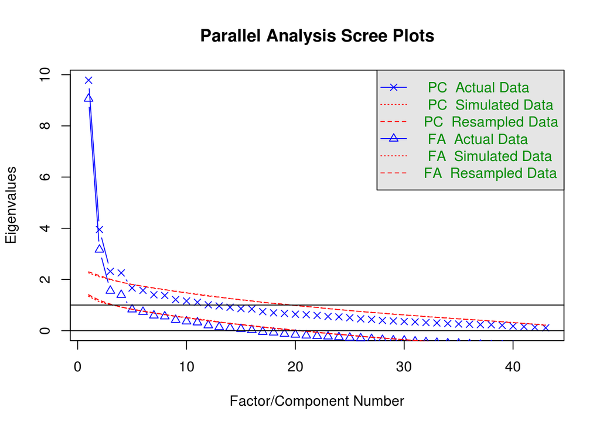

```
## Parallel analysis suggests that the number of factors =  4  and the number of components =  4
```

```r
# Defining factors
auto  <- fa.parallel(fullScale, fm="minres", fa="both", ylabel="Eigenvalues") # yields 4 components and 4 factors
```

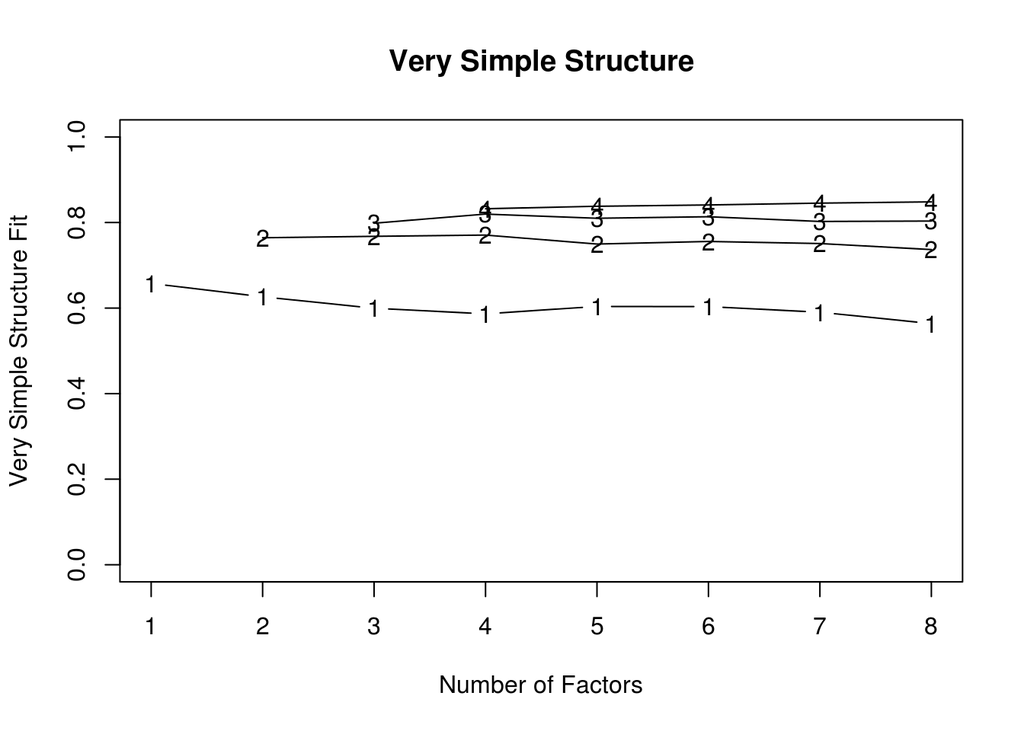

```
##
## Very Simple Structure
## Call: vss(x = x, n = n, rotate = rotate, diagonal = diagonal, fm = fm,
##     n.obs = n.obs, plot = plot, title = title)
## VSS complexity 1 achieves a maximimum of 0.66  with  1  factors
## VSS complexity 2 achieves a maximimum of 0.77  with  4  factors
##
## The Velicer MAP achieves a minimum of 0.01  with  4  factors
## BIC achieves a minimum of  -2741  with  2  factors
## Sample Size adjusted BIC achieves a minimum of  -383.9  with  7  factors
##
## Statistics by number of factors
##   vss1 vss2   map dof chisq    prob sqresid  fit RMSEA   BIC SABIC complex
## 1 0.66 0.00 0.022 860  1628 5.4e-50      49 0.66 0.092 -2597   124     1.0
## 2 0.63 0.76 0.015 818  1278 8.6e-23      34 0.76 0.076 -2741  -153     1.6
## 3 0.60 0.77 0.014 777  1099 1.7e-13      29 0.80 0.068 -2718  -260     1.9
## 4 0.59 0.77 0.013 737   968 1.8e-08      24 0.83 0.062 -2652  -321     2.2
## 5 0.60 0.75 0.013 698   869 1.0e-05      22 0.85 0.057 -2560  -352     2.5
## 6 0.60 0.76 0.014 660   786 4.9e-04      20 0.86 0.054 -2456  -368     2.7
## 7 0.59 0.75 0.014 623   706 1.2e-02      18 0.87 0.049 -2355  -384     2.9
## 8 0.56 0.74 0.015 587   643 5.3e-02      16 0.89 0.047 -2240  -383     3.1
##   eChisq  SRMR eCRMS  eBIC
## 1   2981 0.110 0.113 -1244
## 2   1550 0.079 0.083 -2469
## 3   1182 0.069 0.075 -2635
## 4    848 0.059 0.065 -2773
## 5    698 0.053 0.061 -2731
## 6    613 0.050 0.058 -2630
## 7    522 0.046 0.056 -2538
## 8    427 0.042 0.052 -2457
```

```r
VSS(fullScale, rotate="none") # VSS = 2; MAP = 4 factors
```

```r
# Factor Analysis using polychoric correlations
faAll <- fa.poly(fullScale, nfactors = 2, rotate = "oblimin", fm="minres")
```

```
## The items do not have an equal number of response alternatives, global set to FALSE
```

```r
print.psych(faAll, digits=2, cut= .3)
```

```
## Factor Analysis using method =  minres
## Call: fa.poly(x = fullScale, nfactors = 2, rotate = "oblimin", fm = "minres")
## Standardized loadings (pattern matrix) based upon correlation matrix
##         MR1   MR2    h2   u2 com
## pp001 -0.49       0.282 0.72 1.0
## pp002  0.65       0.414 0.59 1.0
## pp003             0.026 0.97 1.2
## pp004  0.71       0.492 0.51 1.0
## pp005  0.73       0.575 0.42 1.0
## pp006  0.60       0.358 0.64 1.0
## pp007  0.75       0.574 0.43 1.0
## pp008             0.016 0.98 1.2
## pp009  0.63       0.390 0.61 1.0
## pp010 -0.56       0.256 0.74 1.2
## pp011        0.39 0.119 0.88 1.4
## pp012        0.68 0.456 0.54 1.0
## pp013        0.38 0.143 0.86 1.0
## pp014        0.65 0.435 0.56 1.0
## pp015        0.30 0.197 0.80 1.8
## pp016  0.70       0.515 0.49 1.0
## pp017        0.33 0.172 0.83 1.3
## pp018        0.49 0.194 0.81 1.3
## pp019        0.71 0.413 0.59 1.2
## pp020  0.70       0.593 0.41 1.1
## pp021 -0.31       0.204 0.80 1.8
## pp022        0.65 0.467 0.53 1.0
## pp023        0.53 0.403 0.60 1.3
## pp024        0.61 0.467 0.53 1.1
## pp025        0.55 0.310 0.69 1.0
## pp026  0.54       0.357 0.64 1.1
## pp027 -0.71       0.446 0.55 1.0
## pp028 -0.44       0.200 0.80 1.0
## pp029        0.47 0.177 0.82 1.5
## pp030        0.67 0.445 0.55 1.0
## pp031             0.185 0.82 1.9
## pp032 -0.60       0.393 0.61 1.0
## pp033        0.59 0.432 0.57 1.1
## pp034        0.39 0.334 0.67 1.8
## pp035        0.61 0.403 0.60 1.0
## pp036             0.021 0.98 1.2
```

[output cut: 26 more lines]

```
## The root mean square of the residuals (RMSR) is  0.07
## The df corrected root mean square of the residuals is  0.08
##
## The harmonic number of observations is  136 with the empirical chi square  1332  with prob <  2.8e-27
## The total number of observations was  136  with MLE Chi Square =  1237  with prob <  1.2e-19
##
## Tucker Lewis Index of factoring reliability =  0.761
## RMSEA index =  0.073  and the 90 % confidence intervals are  0.054 0.068
## BIC =  -2782
## Fit based upon off diagonal values = 0.93
## Measures of factor score adequacy
##                                                 MR1  MR2
## Correlation of scores with factors             0.97 0.95
## Multiple R square of scores with factors       0.93 0.91
## Minimum correlation of possible factor scores  0.86 0.82
```

```r
## V1 - Items with good loadings ----
# V1 - Version
v1Scale  <- subset(fullScale, select = -c(3,8,15,31,36,41))

# Factor analysis using polychoric correlations
fav1 <- fa.poly(v1Scale, nfactors = 2, rotate = "oblimin", fm="minres")
```

```
## The items do not have an equal number of response alternatives, global set to FALSE
```

```r
print.psych(fav1, digits=2, cut=0.3)
```

```
## Factor Analysis using method =  minres
## Call: fa.poly(x = v1Scale, nfactors = 2, rotate = "oblimin", fm = "minres")
## Standardized loadings (pattern matrix) based upon correlation matrix
##         MR1   MR2   h2   u2 com
## pp001 -0.49       0.28 0.72 1.0
## pp002  0.66       0.42 0.58 1.0
## pp004  0.70       0.48 0.52 1.0
## pp005  0.74       0.58 0.42 1.0
## pp006  0.60       0.35 0.65 1.0
## pp007  0.76       0.58 0.42 1.0
## pp009  0.63       0.39 0.61 1.0
## pp010 -0.56       0.26 0.74 1.2
## pp011        0.38 0.12 0.88 1.4
## pp012        0.67 0.45 0.55 1.0
## pp013        0.38 0.14 0.86 1.0
## pp014        0.64 0.43 0.57 1.0
## pp016  0.70       0.51 0.49 1.0
## pp017        0.33 0.17 0.83 1.3
## pp018        0.49 0.19 0.81 1.3
## pp019        0.71 0.41 0.59 1.2
## pp020  0.70       0.59 0.41 1.1
## pp021 -0.31       0.20 0.80 1.8
## pp022        0.66 0.47 0.53 1.0
## pp023        0.53 0.40 0.60 1.3
## pp024        0.62 0.48 0.52 1.1
## pp025        0.55 0.31 0.69 1.0
## pp026  0.54       0.36 0.64 1.1
## pp027 -0.71       0.45 0.55 1.0
## pp028 -0.45       0.20 0.80 1.0
## pp029        0.46 0.17 0.83 1.5
## pp030        0.68 0.45 0.55 1.0
## pp032 -0.60       0.39 0.61 1.0
## pp033        0.60 0.44 0.56 1.1
## pp034        0.40 0.34 0.66 1.8
## pp035        0.61 0.41 0.59 1.0
## pp037        0.45 0.30 0.70 1.3
## pp038 -0.44       0.37 0.63 1.7
## pp039 -0.57       0.39 0.61 1.1
## pp040       -0.51 0.43 0.57 1.4
## pp042       -0.45 0.39 0.61 1.7
```

[output cut: 20 more lines]

```
## The root mean square of the residuals (RMSR) is  0.07
## The df corrected root mean square of the residuals is  0.08
##
## The harmonic number of observations is  136 with the empirical chi square  940.4  with prob <  3.4e-18
## The total number of observations was  136  with MLE Chi Square =  963.3  with prob <  4.3e-20
##
## Tucker Lewis Index of factoring reliability =  0.777
## RMSEA index =  0.078  and the 90 % confidence intervals are  0.06 0.075
## BIC =  -1950
## Fit based upon off diagonal values = 0.94
## Measures of factor score adequacy
##                                                 MR1  MR2
## Correlation of scores with factors             0.96 0.95
## Multiple R square of scores with factors       0.93 0.91
## Minimum correlation of possible factor scores  0.86 0.82
```

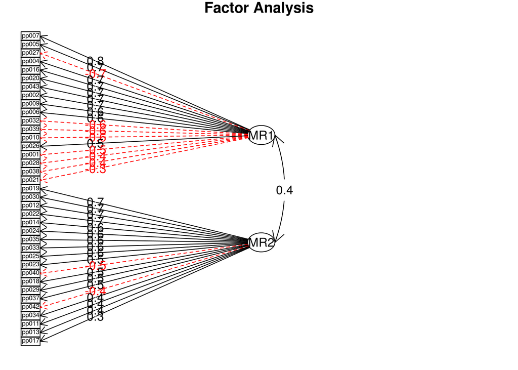